# 자료 전처리

### [1] 데이터 불러오기

```python
# 라이브러리 호출
import pandas as pd
import numpy as np
import matplotlib.pyplot as plt
from sklearn.preprocessing import LabelEncoder
import seaborn as sns
```

```python
# 데이터 불러오기
train = pd.read_csv('./data/train.csv')
test = pd.read_csv('./data/test.csv')
```

```python
train.head()
```

|  | PassengerId | HomePlanet | CryoSleep | Cabin | Destination | Age | VIP | RoomService | FoodCourt | ShoppingMall | Spa | VRDeck | Name | Transported |
| --- | --- | --- | --- | --- | --- | --- | --- | --- | --- | --- | --- | --- | --- | --- |
| 0 | 0001_01 | Europa | False | B/0/P | TRAPPIST-1e | 39.0 | False | 0.0 | 0.0 | 0.0 | 0.0 | 0.0 | Maham Ofracculy | False |
| 1 | 0002_01 | Earth | False | F/0/S | TRAPPIST-1e | 24.0 | False | 109.0 | 9.0 | 25.0 | 549.0 | 44.0 | Juanna Vines | True |
| 2 | 0003_01 | Europa | False | A/0/S | TRAPPIST-1e | 58.0 | True | 43.0 | 3576.0 | 0.0 | 6715.0 | 49.0 | Altark Susent | False |
| 3 | 0003_02 | Europa | False | A/0/S | TRAPPIST-1e | 33.0 | False | 0.0 | 1283.0 | 371.0 | 3329.0 | 193.0 | Solam Susent | False |
| 4 | 0004_01 | Earth | False | F/1/S | TRAPPIST-1e | 16.0 | False | 303.0 | 70.0 | 151.0 | 565.0 | 2.0 | Willy Santantines | True |

```python
# 데이터 모양 살펴보기
train.shape, test.shape
```

```
((8693, 14), (4277, 13))
```

```python
# 데이터 컬럼 확인
train.columns, test.columns
```

```
(Index(['PassengerId', 'HomePlanet', 'CryoSleep', 'Cabin', 'Destination', 'Age',
        'VIP', 'RoomService', 'FoodCourt', 'ShoppingMall', 'Spa', 'VRDeck',
        'Name', 'Transported'],
       dtype='object'),
 Index(['PassengerId', 'HomePlanet', 'CryoSleep', 'Cabin', 'Destination', 'Age',
        'VIP', 'RoomService', 'FoodCourt', 'ShoppingMall', 'Spa', 'VRDeck',
        'Name'],
       dtype='object'))
```

0 PassengerId : 승객 번호 gggg-pp로 생격는데 같은 gggg면 가족일수도 있음  
1 HomePlanet : 출신 행성  
2 CryoSleep : 냉동 수면 여부  
3 Cabin : 선실 번호  
4 Destination : 목적지  
5 Age : 연령  
6 VIP : VIP 여부  
7 RoomService : 룸서비스 비용  
8 FoodCourt : 식품코트 비용  
9 ShoppingMall : 쇼핑몰 비용  
10 Spa : 스파비용  
11 VRDeck : VR 갑판  
12 Name : 이름  
13 Transported : 전송 여부 (예측값)

```python
# 결측치 확인
train.isnull().sum()
```

```
PassengerId       0
HomePlanet      201
CryoSleep       217
Cabin           199
Destination     182
Age             179
VIP             203
RoomService     181
FoodCourt       183
ShoppingMall    208
Spa             183
VRDeck          188
Name            200
Transported       0
dtype: int64
```

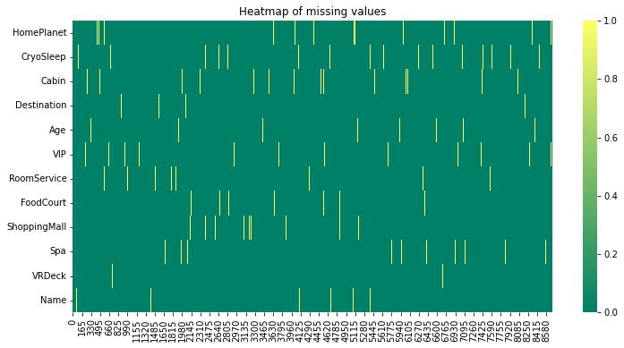

```python
na_cols=train.columns[train.isna().any()].tolist()

# Heatmap of missing values
plt.figure(figsize=(12,6))
sns.heatmap(train[na_cols].isna().T, cmap='summer')
plt.title('Heatmap of missing values')
```

```python
# 중복값 확인
train.duplicated().sum()
```

```
0
```

```python
# 특성 고유값 확인
train.nunique()
```

```
PassengerId     8693
HomePlanet         3
CryoSleep          2
Cabin           6560
Destination        3
Age               80
VIP                2
RoomService     1273
FoodCourt       1507
ShoppingMall    1115
Spa             1327
VRDeck          1306
Name            8473
Transported        2
dtype: int64
```

```python
# 데이터 타입
train.dtypes
```

```
PassengerId      object
HomePlanet       object
CryoSleep        object
Cabin            object
Destination      object
Age             float64
VIP              object
RoomService     float64
FoodCourt       float64
ShoppingMall    float64
Spa             float64
VRDeck          float64
Name             object
Transported        bool
dtype: object
```

#### 문제 2) 자료들을 수치형으로 변환해야 한다

0 PassengerId : 고유의 승객 번호 (8693명)  
1 HomePlanet : 출신 행성 (Earth - 4602 / Europa - 2131 / Mars - 1759 / NA - 201)  
2 CryoSleep : 냉동 수면 여부 (True - 3037 / False - 5439)  
3 Cabin : 선실 번호  
4 Destination : 목적지 (TRAPPIST-1e - 5915 / 55 Cancri e - 1800 / PSO J318.5-22 - 796 / NA - 182)  
5 Age : 연령  
6 VIP : VIP 여부  
7 RoomService : 룸서비스 비용  
8 FoodCourt : 식품코트 비용  
9 ShoppingMall : 쇼핑몰 비용  
10 Spa : 스파비용  
11 VRDeck : VR 갑판  
12 Name : 이름  
13 Transported : 전송 여부 (예측값)

### [2] EDA

**타겟 비중 비교**

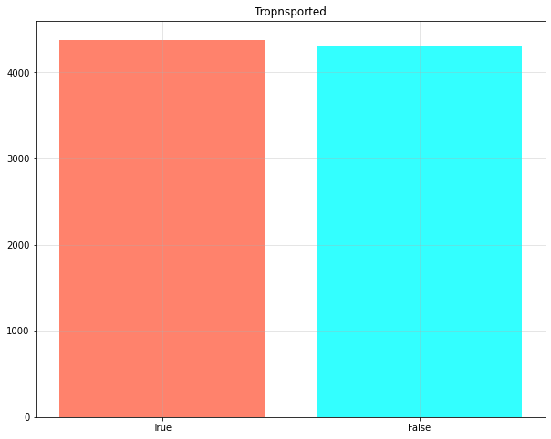

```python
# 타겟 비중에 대한 bar 그래프 시각화
plt.figure(figsize = (10,8))
plt.bar(['True', 'False'], train['Transported'].value_counts(), color = ['tomato', 'cyan'], alpha = .8)
plt.title('Tropnsported')
plt.grid(True, alpha = 0.4)
```

전송된 사람과 전송되지 않는 사람의 수는 비슷하다.  
따라서 Taget의 비중에 의한 적합문제는 신경쓰지 않아도 된다.

**연속형 변수**

연령

```
No artists with labels found to put in legend.  Note that artists whose label start with an underscore are ignored when legend() is called with no argument.
```

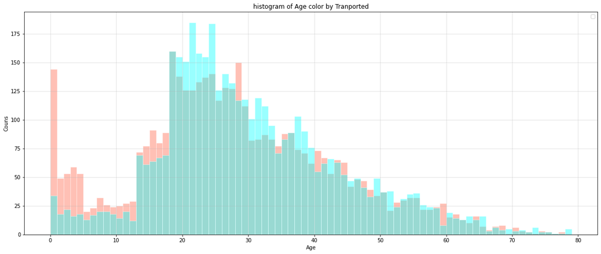

```python
# 연령 데이터 시각화
plt.figure(figsize = (20, 8))

plt.hist(train[train['Transported'] == True]['Age'], color='tomato', alpha = .4, bins = 78, edgecolor = 'white')
plt.hist(train[train['Transported'] == False]['Age'], color='cyan', alpha = .4, bins = 79, edgecolor = 'white')
plt.title('histogram of Age color by Tranported')
plt.xlabel('Age')
plt.ylabel('Couns')
plt.grid(True, alpha = .4)
plt.legend()
plt.show()
```

위의 그래프로 알 수 있는 사실

```
- 0세에서 18세 사이의 경우, 전송된 경우가 더 많음
- 18세에서 35세 사이의 경우, 전송이 되지 않는 경우가 더 많음
- 35세 이상의 경우 비슷한 양상을 보임
```

**'아이'/'청년'/'중년 이상'으로 구분되는 연령대라는 컬럼을 추가하여 구분할 수 있음**

여가시설 활용

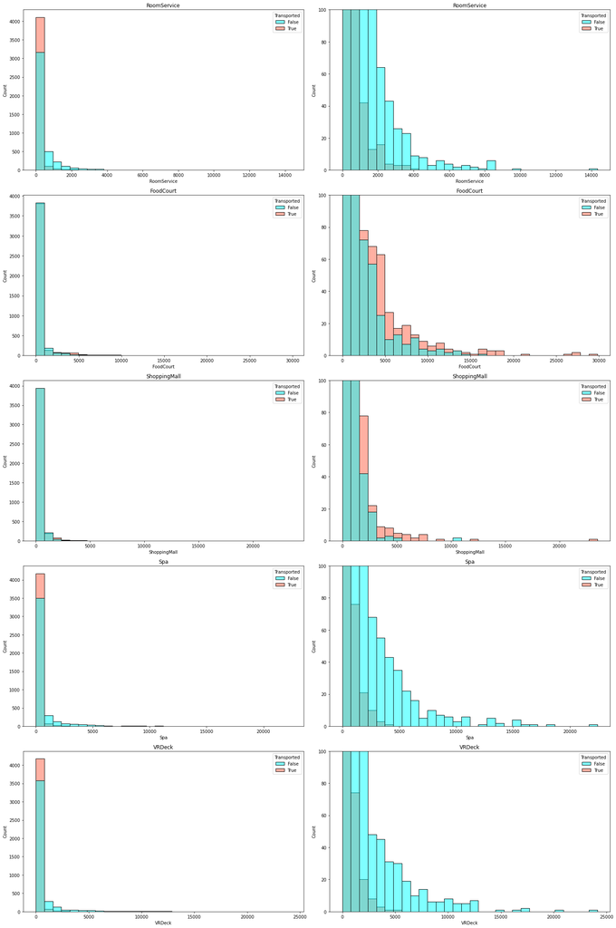

```python
# 여가 시설과 관련된 컬럼명
exp_feats = ['RoomService', 'FoodCourt', 'ShoppingMall', 'Spa', 'VRDeck']

# 각각의 특성별 분포도 그래프 그리기
fig = plt.figure(figsize=(20,30))
for i, var_name in enumerate(exp_feats) :
    # 전체 모습을 나타내는 그래프
    ax=fig.add_subplot(5, 2, 2 * i + 1)
    sns.histplot(data=train, x=var_name, axes=ax, bins=30, kde=False, hue='Transported', palette=['cyan','tomato'])
    ax.set_title(var_name)

    # 확대된 그래프
    ax=fig.add_subplot(5, 2, 2 * i + 2)
    sns.histplot(data=train, x=var_name, axes=ax, bins=30, kde=False, hue='Transported', palette=['cyan','tomato'])
    ax.set_title(var_name)
    plt.ylim([0,100])
fig.tight_layout()  # Improves appearance a bit
plt.show()
```

위의 그래프를 보고 알 수 있는 사실

```
- 대부분의 사람들이 돈을 안썻다.(1)
- 지출이 기하급수적으로 떨어진다. (2)
- 이상치는 비교적 소수
- 비교적 전송된 사람들은 적게 썼다.
- 푸드코드와 쇼핑몰은 전송된 사람이 많고, 그 외의 경우는 전송되지 않은 경우가 많다. (3)
```

**(2) - log로 범위 줄이기**  
**(1) - '총 지출' 컬럼 만들기**  
**(1,3) - '지출 여부' 컬럼 만들기**

**범주형 변수**

전체적으로 보기

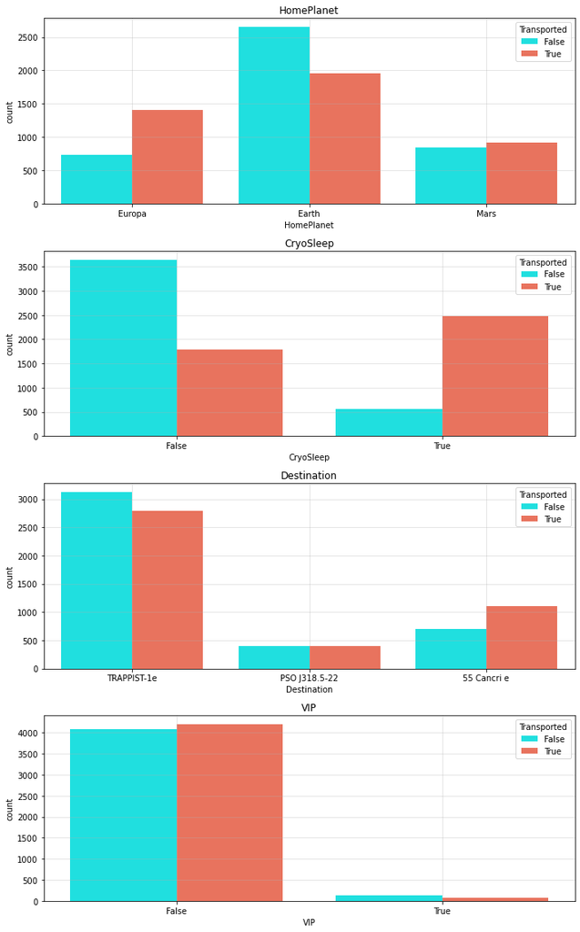

```python
# 범주형 변수
cat_feats=['HomePlanet', 'CryoSleep', 'Destination', 'VIP']

# Plot categorical features
fig=plt.figure(figsize=(10,16))
for i, var_name in enumerate(cat_feats):
    ax=fig.add_subplot(4,1,i+1)
    sns.countplot(data=train, x=var_name, axes=ax, hue='Transported', palette = ['cyan','tomato'])
    ax.set_title(var_name)
    ax.grid(True, alpha = .4)
fig.tight_layout()  # Improves appearance a bit
plt.show()
```

위 그래프를 보고 알 수 있는 점

```
- VIP 특성을 쓸모없어 보임
- 냉동수면 특성은 유용해보임
```

**질적 변수**

승객번호, 선실, 이름은 아직은 EDA를 할 수 없음

```python
# Qualitative features
qual_feats=['PassengerId', 'Cabin' ,'Name']

# Preview qualitative features
train[qual_feats].head()
```

|  | PassengerId | Cabin | Name |
| --- | --- | --- | --- |
| 0 | 0001_01 | B/0/P | Maham Ofracculy |
| 1 | 0002_01 | F/0/S | Juanna Vines |
| 2 | 0003_01 | A/0/S | Altark Susent |
| 3 | 0003_02 | A/0/S | Solam Susent |
| 4 | 0004_01 | F/1/S | Willy Santantines |

위 그래프를 보고 알 수 있는 점

```
- 승객번호의 앞에 네개의 숫자는 그룹을 구분할 수 있음
- 선실 특성은 deck/num/side로 구분 가능
```

**승객 번호에서 그룹과 그룹 수 컬럼 추가 가능**  
**선실 특성은 deck/num/side로 구분 가능**  
**이름 특성에서 성을 추출하여 사용할 수 있음**

### [3] 특성 설계

#### 특성 추가

**연령대 특성**

```python
# 새로운 컬럼 추가

# 훈련 데이터에 연령대 특성 추가
train['Age_group']=np.nan
train.loc[train['Age']<=12,'Age_group']='Age_0-12'
train.loc[(train['Age']>12) & (train['Age']<18),'Age_group']='Age_13-17'
train.loc[(train['Age']>=18) & (train['Age']<=25),'Age_group']='Age_18-25'
train.loc[(train['Age']>25) & (train['Age']<=30),'Age_group']='Age_26-30'
train.loc[(train['Age']>30) & (train['Age']<=50),'Age_group']='Age_31-50'
train.loc[train['Age']>50,'Age_group']='Age_51+'

# 테스트 데이터에 연령대 특성 추가
test['Age_group']=np.nan
test.loc[test['Age']<=12,'Age_group']='Age_0-12'
test.loc[(test['Age']>12) & (test['Age']<18),'Age_group']='Age_13-17'
test.loc[(test['Age']>=18) & (test['Age']<=25),'Age_group']='Age_18-25'
test.loc[(test['Age']>25) & (test['Age']<=30),'Age_group']='Age_26-30'
test.loc[(test['Age']>30) & (test['Age']<=50),'Age_group']='Age_31-50'
test.loc[test['Age']>50,'Age_group']='Age_51+'
```

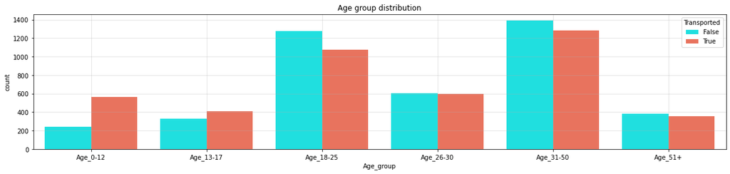

```python
# Plot distribution of new features
plt.figure(figsize=(20,4))
g=sns.countplot(data=train, x='Age_group', hue='Transported', order=['Age_0-12','Age_13-17','Age_18-25','Age_26-30','Age_31-50','Age_51+'], palette = ['cyan','tomato'])
plt.title('Age group distribution')
plt.grid(True, alpha=.4)
```

**지출 특성**

```python
# 지출특성 훈련 데이터에 추가
train['Expenditure']=train[exp_feats].sum(axis=1)
train['No_spending']=(train['Expenditure']==0).astype(int)

# 지출특성 테스트 데이터에 추가
test['Expenditure']=test[exp_feats].sum(axis=1)
test['No_spending']=(test['Expenditure']==0).astype(int)
```

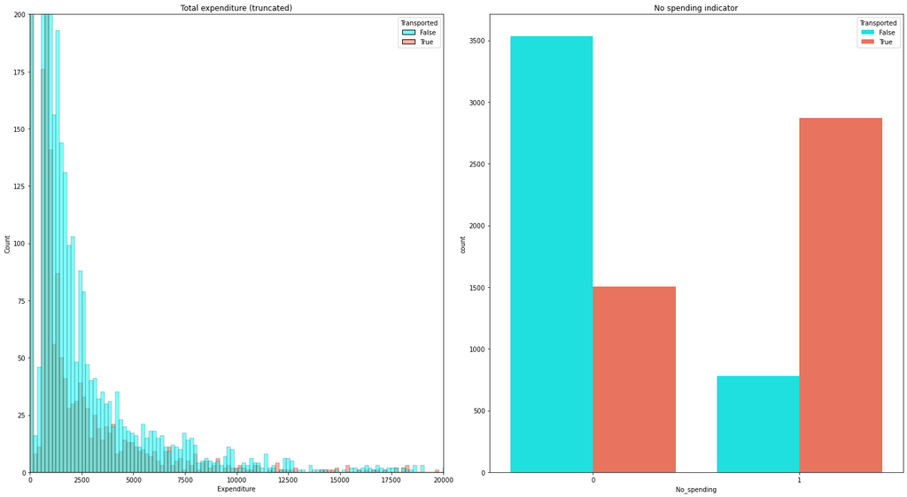

```python
fig=plt.figure(figsize=(20,11))
plt.subplot(1,2,1)
sns.histplot(data=train, x='Expenditure', hue='Transported', bins=200, palette = ['cyan','tomato'])
plt.title('Total expenditure (truncated)')
plt.ylim([0,200])
plt.xlim([0,20000])

plt.subplot(1,2,2)
sns.countplot(data=train, x='No_spending', hue='Transported', palette = ['cyan','tomato'])
plt.title('No spending indicator')
fig.tight_layout()
```

**승객 그룹**

```python
# New feature - Group
train['Group'] = train['PassengerId'].apply(lambda x: x.split('_')[0]).astype(int)
test['Group'] = test['PassengerId'].apply(lambda x: x.split('_')[0]).astype(int)

# New feature - Group size
train['Group_size']=train['Group'].map(lambda x: pd.concat([train['Group'], test['Group']]).value_counts()[x])
test['Group_size']=test['Group'].map(lambda x: pd.concat([train['Group'], test['Group']]).value_counts()[x])
```

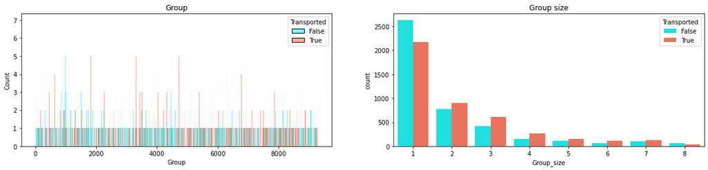

```python
# Plot distribution of new features
plt.figure(figsize=(20,4))
plt.subplot(1,2,1)
sns.histplot(data=train, x='Group', hue='Transported', binwidth=1, palette = ['cyan','tomato'])
plt.title('Group')

plt.subplot(1,2,2)
sns.countplot(data=train, x='Group_size', hue='Transported',palette = ['cyan','tomato'])
plt.title('Group size')
fig.tight_layout()
```

```
(0.0, 3000.0)
```

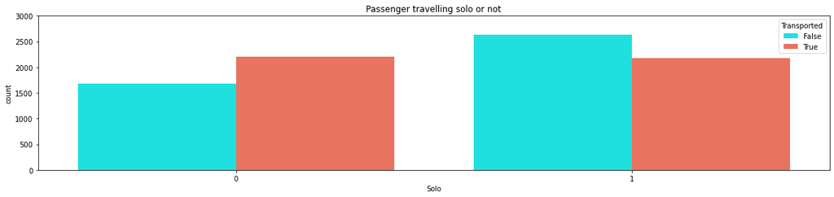

```python
# New feature
train['Solo']=(train['Group_size']==1).astype(int)
test['Solo']=(test['Group_size']==1).astype(int)

# New feature distribution
plt.figure(figsize=(20,4))
sns.countplot(data=train, x='Solo', hue='Transported', palette = ['cyan','tomato'])
plt.title('Passenger travelling solo or not')
plt.ylim([0,3000])
```

**선실 위치**

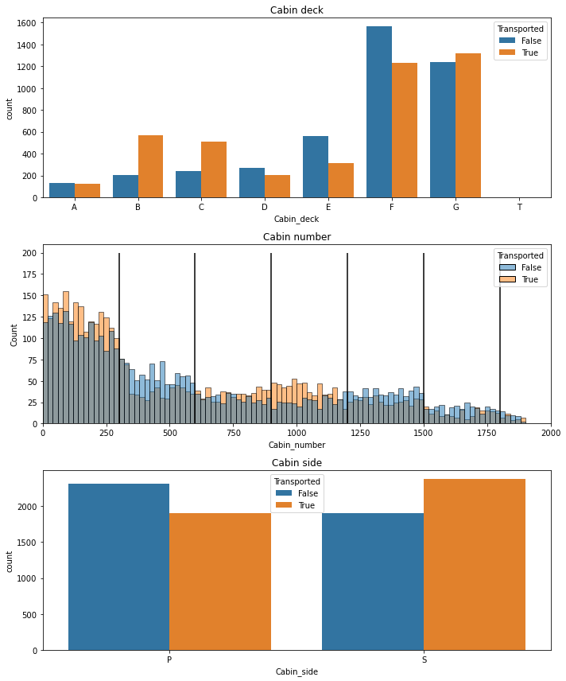

```python
# Replace NaN's with outliers for now (so we can split feature)
train['Cabin'].fillna('Z/9999/Z', inplace=True)
test['Cabin'].fillna('Z/9999/Z', inplace=True)

# New features - training set
train['Cabin_deck'] = train['Cabin'].apply(lambda x: x.split('/')[0])
train['Cabin_number'] = train['Cabin'].apply(lambda x: x.split('/')[1]).astype(int)
train['Cabin_side'] = train['Cabin'].apply(lambda x: x.split('/')[2])

# New features - test set
test['Cabin_deck'] = test['Cabin'].apply(lambda x: x.split('/')[0])
test['Cabin_number'] = test['Cabin'].apply(lambda x: x.split('/')[1]).astype(int)
test['Cabin_side'] = test['Cabin'].apply(lambda x: x.split('/')[2])

# Put Nan's back in (we will fill these later)
train.loc[train['Cabin_deck']=='Z', 'Cabin_deck']=np.nan
train.loc[train['Cabin_number']==9999, 'Cabin_number']=np.nan
train.loc[train['Cabin_side']=='Z', 'Cabin_side']=np.nan
test.loc[test['Cabin_deck']=='Z', 'Cabin_deck']=np.nan
test.loc[test['Cabin_number']==9999, 'Cabin_number']=np.nan
test.loc[test['Cabin_side']=='Z', 'Cabin_side']=np.nan

# Drop Cabin (we don't need it anymore)
train.drop('Cabin', axis=1, inplace=True)
test.drop('Cabin', axis=1, inplace=True)

# Plot distribution of new features
fig=plt.figure(figsize=(10,12))
plt.subplot(3,1,1)
sns.countplot(data=train, x='Cabin_deck', hue='Transported', order=['A','B','C','D','E','F','G','T'])
plt.title('Cabin deck')

plt.subplot(3,1,2)
sns.histplot(data=train, x='Cabin_number', hue='Transported',binwidth=20)
plt.vlines(300, ymin=0, ymax=200, color='black')
plt.vlines(600, ymin=0, ymax=200, color='black')
plt.vlines(900, ymin=0, ymax=200, color='black')
plt.vlines(1200, ymin=0, ymax=200, color='black')
plt.vlines(1500, ymin=0, ymax=200, color='black')
plt.vlines(1800, ymin=0, ymax=200, color='black')
plt.title('Cabin number')
plt.xlim([0,2000])

plt.subplot(3,1,3)
sns.countplot(data=train, x='Cabin_side', hue='Transported')
plt.title('Cabin side')
fig.tight_layout()
```

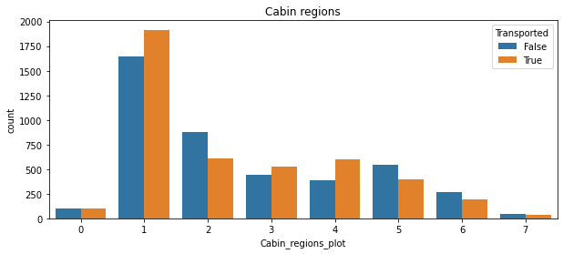

```python
# New features - training set
train['Cabin_region1']=(train['Cabin_number']<300).astype(int)   # one-hot encoding
train['Cabin_region2']=((train['Cabin_number']>=300) & (train['Cabin_number']<600)).astype(int)
train['Cabin_region3']=((train['Cabin_number']>=600) & (train['Cabin_number']<900)).astype(int)
train['Cabin_region4']=((train['Cabin_number']>=900) & (train['Cabin_number']<1200)).astype(int)
train['Cabin_region5']=((train['Cabin_number']>=1200) & (train['Cabin_number']<1500)).astype(int)
train['Cabin_region6']=((train['Cabin_number']>=1500) & (train['Cabin_number']<1800)).astype(int)
train['Cabin_region7']=(train['Cabin_number']>=1800).astype(int)

# New features - test set
test['Cabin_region1']=(test['Cabin_number']<300).astype(int)   # one-hot encoding
test['Cabin_region2']=((test['Cabin_number']>=300) & (test['Cabin_number']<600)).astype(int)
test['Cabin_region3']=((test['Cabin_number']>=600) & (test['Cabin_number']<900)).astype(int)
test['Cabin_region4']=((test['Cabin_number']>=900) & (test['Cabin_number']<1200)).astype(int)
test['Cabin_region5']=((test['Cabin_number']>=1200) & (test['Cabin_number']<1500)).astype(int)
test['Cabin_region6']=((test['Cabin_number']>=1500) & (test['Cabin_number']<1800)).astype(int)
test['Cabin_region7']=(test['Cabin_number']>=1800).astype(int)

# Plot distribution of new features
plt.figure(figsize=(10,4))
train['Cabin_regions_plot']=(train['Cabin_region1']+2*train['Cabin_region2']+3*train['Cabin_region3']+4*train['Cabin_region4']+5*train['Cabin_region5']+6*train['Cabin_region6']+7*train['Cabin_region7']).astype(int)
sns.countplot(data=train, x='Cabin_regions_plot', hue='Transported')
plt.title('Cabin regions')
train.drop('Cabin_regions_plot', axis=1, inplace=True)
```

**성-이름**

```python
# Replace NaN's with outliers for now (so we can split feature)
train['Name'].fillna('Unknown Unknown', inplace=True)
test['Name'].fillna('Unknown Unknown', inplace=True)

# New feature - Surname
train['Surname']=train['Name'].str.split().str[-1]
test['Surname']=test['Name'].str.split().str[-1]

# New feature - Family size
train['Family_size']=train['Surname'].map(lambda x: pd.concat([train['Surname'],test['Surname']]).value_counts()[x])
test['Family_size']=test['Surname'].map(lambda x: pd.concat([train['Surname'],test['Surname']]).value_counts()[x])

# Put Nan's back in (we will fill these later)
train.loc[train['Surname']=='Unknown','Surname']=np.nan
train.loc[train['Family_size']>100,'Family_size']=np.nan
test.loc[test['Surname']=='Unknown','Surname']=np.nan
test.loc[test['Family_size']>100,'Family_size']=np.nan

# Drop name (we don't need it anymore)
train.drop('Name', axis=1, inplace=True)
test.drop('Name', axis=1, inplace=True)
```

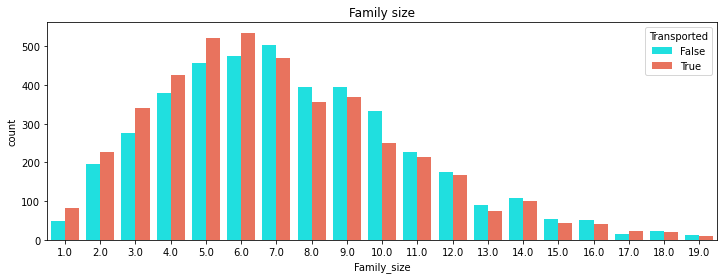

```python
# New feature distribution
plt.figure(figsize=(12,4))
sns.countplot(data=train, x='Family_size', hue='Transported', palette = ['cyan','tomato'])
plt.title('Family size')
```

#### 결측치 다루기

```python
# Labels and features
y=train['Transported'].copy().astype(int)
X=train.drop('Transported', axis=1).copy()

# Concatenate dataframes
data=pd.concat([X, test], axis=0).reset_index(drop=True)
```

각 컬럼별 결측치는 비교적 적지만 결측치가 존재하는 행을 지울 경우 너무 많은 데이터가 날아감

### 결측치 제어 전략

Group 컬럼과 HomePlanet 컬럼

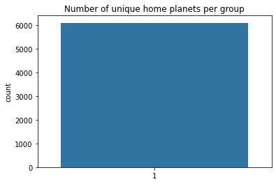

```python
# Joint distribution of Group and HomePlanet
GHP_gb=train.groupby(['Group','HomePlanet'])['HomePlanet'].size().unstack().fillna(0)
GHP_gb.head()

# Countplot of unique values
sns.countplot((GHP_gb>0).sum(axis=1))
plt.title('Number of unique home planets per group')
```

위의 그래프를 통해 같은 그룹의 사람들은 모두 같은 행성에서 출발 했음을 알 수 있음

```python
# Missing values before
HP_bef=data['HomePlanet'].isna().sum()

# Passengers with missing HomePlanet and in a group with known HomePlanet
GHP_index=data[data['HomePlanet'].isna()][(data[data['HomePlanet'].isna()]['Group']).isin(GHP_gb.index)].index

# Fill corresponding missing values
data.loc[GHP_index,'HomePlanet']=data.iloc[GHP_index,:]['Group'].map(lambda x: GHP_gb.idxmax(axis=1)[x])

# Print number of missing values left
print('#HomePlanet missing values before:',HP_bef)
print('#HomePlanet missing values after:',data['HomePlanet'].isna().sum())
```

```
#HomePlanet missing values before: 288
#HomePlanet missing values after: 198
```

이전에 비해서 결측치가 줄었지만 여전히 줄여야된다

**HomePlanet과 CabinDeck**

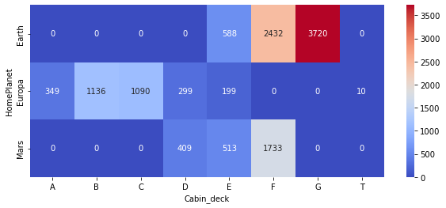

```python
# Joint distribution of CabinDeck and HomePlanet
CDHP_gb=data.groupby(['Cabin_deck','HomePlanet'])['HomePlanet'].size().unstack().fillna(0)

# Heatmap of missing values
plt.figure(figsize=(10,4))
sns.heatmap(CDHP_gb.T, annot=True, fmt='g', cmap='coolwarm')
```

A, B, C, T 선실을 사용하는 사람은 Europa 출신  
G는 Earth 출신  
D, E, F는 특정행성이 아닌 다양한 행성이 뒤섞여있음

```python
# Missing values before
HP_bef=data['HomePlanet'].isna().sum()

# Decks A, B, C or T came from Europa
data.loc[(data['HomePlanet'].isna()) & (data['Cabin_deck'].isin(['A', 'B', 'C', 'T'])), 'HomePlanet']='Europa'

# Deck G came from Earth
data.loc[(data['HomePlanet'].isna()) & (data['Cabin_deck']=='G'), 'HomePlanet']='Earth'

# Print number of missing values left
print('#HomePlanet missing values before:',HP_bef)
print('#HomePlanet missing values after:',data['HomePlanet'].isna().sum())
```

```
#HomePlanet missing values before: 198
#HomePlanet missing values after: 114
```

**HomePlanet과 Surname**

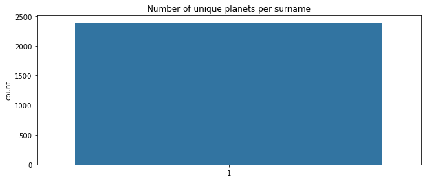

```python
# Joint distribution of Surname and HomePlanet
SHP_gb=data.groupby(['Surname','HomePlanet'])['HomePlanet'].size().unstack().fillna(0)

# Countplot of unique values
plt.figure(figsize=(10,4))
sns.countplot((SHP_gb>0).sum(axis=1))
plt.title('Number of unique planets per surname')
```

성이 같으면 출신행성도 같음

```python
# Missing values before
HP_bef=data['HomePlanet'].isna().sum()

# Passengers with missing HomePlanet and in a family with known HomePlanet
SHP_index=data[data['HomePlanet'].isna()][(data[data['HomePlanet'].isna()]['Surname']).isin(SHP_gb.index)].index

# Fill corresponding missing values
data.loc[SHP_index,'HomePlanet']=data.iloc[SHP_index,:]['Surname'].map(lambda x: SHP_gb.idxmax(axis=1)[x])

# Print number of missing values left
print('#HomePlanet missing values before:',HP_bef)
print('#HomePlanet missing values after:',data['HomePlanet'].isna().sum())
```

```
#HomePlanet missing values before: 114
#HomePlanet missing values after: 12
```

**HomePlanet과 Destination**

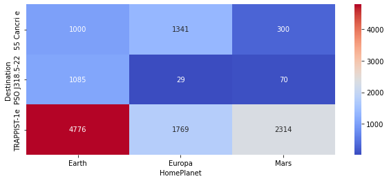

```python
# Joint distribution of HomePlanet and Destination
HPD_gb=data.groupby(['HomePlanet','Destination'])['Destination'].size().unstack().fillna(0)

# Heatmap of missing values
plt.figure(figsize=(10,4))
sns.heatmap(HPD_gb.T, annot=True, fmt='g', cmap='coolwarm')
```

대다수의 Earth 출신 사람들의 목적지가 TRAPPIST-1e가 목적지니 결측치를 다수에 따라감

```python
# Missing values before
HP_bef=data['HomePlanet'].isna().sum()

# Fill remaining HomePlanet missing values with Earth (if not on deck D) or Mars (if on Deck D)
data.loc[(data['HomePlanet'].isna()) & ~(data['Cabin_deck']=='D'), 'HomePlanet']='Earth'
data.loc[(data['HomePlanet'].isna()) & (data['Cabin_deck']=='D'), 'HomePlanet']='Mars'

# Print number of missing values left
print('#HomePlanet missing values before:',HP_bef)
print('#HomePlanet missing values after:',data['HomePlanet'].isna().sum())
```

```
#HomePlanet missing values before: 12
#HomePlanet missing values after: 0
```

HomePlanet 결측치 제거 완료

**Destination**  
과반수 이상이 TRAPPIST-1e로 향하고 있으므로 동일하게 대체

```python
# Missing values before
D_bef=data['Destination'].isna().sum()

# Fill missing Destination values with mode
data.loc[(data['Destination'].isna()), 'Destination']='TRAPPIST-1e'

# Print number of missing values left
print('#Destination missing values before:',D_bef)
print('#Destination missing values after:',data['Destination'].isna().sum())
```

```
#Destination missing values before: 274
#Destination missing values after: 0
```

**Surnamer과 group**

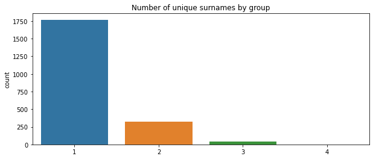

```python
# Joint distribution of Group and Surname
GSN_gb=data[data['Group_size']>1].groupby(['Group','Surname'])['Surname'].size().unstack().fillna(0)

# Countplot of unique values
plt.figure(figsize=(10,4))
sns.countplot((GSN_gb>0).sum(axis=1))
plt.title('Number of unique surnames by group')
```

```python
# Missing values before
SN_bef=data['Surname'].isna().sum()

# Passengers with missing Surname and in a group with known majority Surname
GSN_index=data[data['Surname'].isna()][(data[data['Surname'].isna()]['Group']).isin(GSN_gb.index)].index

# Fill corresponding missing values
data.loc[GSN_index,'Surname']=data.iloc[GSN_index,:]['Group'].map(lambda x: GSN_gb.idxmax(axis=1)[x])

# Print number of missing values left
print('#Surname missing values before:',SN_bef)
print('#Surname missing values after:',data['Surname'].isna().sum())
```

```
#Surname missing values before: 294
#Surname missing values after: 155
```

```python
# Replace NaN's with outliers (so we can use map)
data['Surname'].fillna('Unknown', inplace=True)

# Update family size feature
data['Family_size']=data['Surname'].map(lambda x: data['Surname'].value_counts()[x])

# Put NaN's back in place of outliers
data.loc[data['Surname']=='Unknown','Surname']=np.nan

# Say unknown surname means no family
data.loc[data['Family_size']>100,'Family_size']=0
```

**CabinSide과 Group**

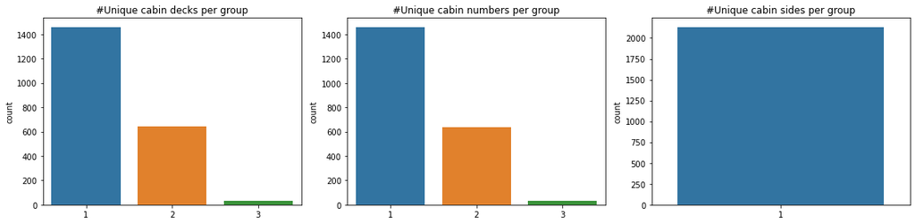

```python
# Joint distribution of Group and Cabin features
GCD_gb=data[data['Group_size']>1].groupby(['Group','Cabin_deck'])['Cabin_deck'].size().unstack().fillna(0)
GCN_gb=data[data['Group_size']>1].groupby(['Group','Cabin_number'])['Cabin_number'].size().unstack().fillna(0)
GCS_gb=data[data['Group_size']>1].groupby(['Group','Cabin_side'])['Cabin_side'].size().unstack().fillna(0)

# Countplots
fig=plt.figure(figsize=(16,4))
plt.subplot(1,3,1)
sns.countplot((GCD_gb>0).sum(axis=1))
plt.title('#Unique cabin decks per group')

plt.subplot(1,3,2)
sns.countplot((GCN_gb>0).sum(axis=1))
plt.title('#Unique cabin numbers per group')

plt.subplot(1,3,3)
sns.countplot((GCS_gb>0).sum(axis=1))
plt.title('#Unique cabin sides per group')
fig.tight_layout()
```

```python
# Missing values before
CS_bef=data['Cabin_side'].isna().sum()

# Passengers with missing Cabin side and in a group with known Cabin side
GCS_index=data[data['Cabin_side'].isna()][(data[data['Cabin_side'].isna()]['Group']).isin(GCS_gb.index)].index

# Fill corresponding missing values
data.loc[GCS_index,'Cabin_side']=data.iloc[GCS_index,:]['Group'].map(lambda x: GCS_gb.idxmax(axis=1)[x])

# Print number of missing values left
print('#Cabin_side missing values before:',CS_bef)
print('#Cabin_side missing values after:',data['Cabin_side'].isna().sum())
```

```
#Cabin_side missing values before: 299
#Cabin_side missing values after: 162
```

**CabinSide와 Surname**

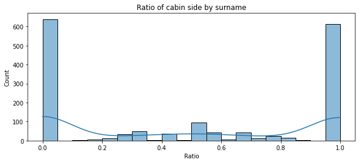

```python
# Joint distribution of Surname and Cabin side
SCS_gb=data[data['Group_size']>1].groupby(['Surname','Cabin_side'])['Cabin_side'].size().unstack().fillna(0)

# Ratio of sides
SCS_gb['Ratio']=SCS_gb['P']/(SCS_gb['P']+SCS_gb['S'])

# Histogram of ratio
plt.figure(figsize=(10,4))
sns.histplot(SCS_gb['Ratio'], kde=True, binwidth=0.05)
plt.title('Ratio of cabin side by surname')
```

```python
# Print proportion
print('Percentage of families all on the same cabin side:', 100*np.round((SCS_gb['Ratio'].isin([0,1])).sum()/len(SCS_gb),3),'%')

# Another view of the same information
SCS_gb.head()
```

```
Percentage of families all on the same cabin side: 76.7 %
```

| Cabin_side Surname | P | S | Ratio |
| --- | --- | --- | --- |
| Acobson | 0.0 | 3.0 | 0.0 |
| Acobsond | 3.0 | 0.0 | 1.0 |
| Adavisons | 6.0 | 0.0 | 1.0 |
| Admingried | 0.0 | 4.0 | 0.0 |
| Aginge | 3.0 | 0.0 | 1.0 |

위의 그래프로 같은 성씨들은 같은 cabin side를 가지는 걸 볼 수 있음

```python
# Missing values before
CS_bef=data['Cabin_side'].isna().sum()

# Drop ratio column
SCS_gb.drop('Ratio', axis=1, inplace=True)

# Passengers with missing Cabin side and in a family with known Cabin side
SCS_index=data[data['Cabin_side'].isna()][(data[data['Cabin_side'].isna()]['Surname']).isin(SCS_gb.index)].index

# Fill corresponding missing values
data.loc[SCS_index,'Cabin_side']=data.iloc[SCS_index,:]['Surname'].map(lambda x: SCS_gb.idxmax(axis=1)[x])

# Drop surname (we don't need it anymore)
data.drop('Surname', axis=1, inplace=True)

# Print number of missing values left
print('#Cabin_side missing values before:',CS_bef)
print('#Cabin_side missing values after:',data['Cabin_side'].isna().sum())
```

```
#Cabin_side missing values before: 162
#Cabin_side missing values after: 66
```

여기까지가 cabin_side의 결측치를 제어할 수 있는 방법이고  
나머지 것들은 이상치로 제어하자

```python
# Missing values before
CS_bef=data['Cabin_side'].isna().sum()

# Fill remaining missing values with outlier
data.loc[data['Cabin_side'].isna(),'Cabin_side']='Z'

# Print number of missing values left
print('#Cabin_side missing values before:',CS_bef)
print('#Cabin_side missing values after:',data['Cabin_side'].isna().sum())
```

```
#Cabin_side missing values before: 66
#Cabin_side missing values after: 0
```

```python
# Missing values before
CD_bef=data['Cabin_deck'].isna().sum()

# Passengers with missing Cabin deck and in a group with known majority Cabin deck
GCD_index=data[data['Cabin_deck'].isna()][(data[data['Cabin_deck'].isna()]['Group']).isin(GCD_gb.index)].index

# Fill corresponding missing values
data.loc[GCD_index,'Cabin_deck']=data.iloc[GCD_index,:]['Group'].map(lambda x: GCD_gb.idxmax(axis=1)[x])

# Print number of missing values left
print('#Cabin_deck missing values before:',CD_bef)
print('#Cabin_deck missing values after:',data['Cabin_deck'].isna().sum())
```

```
#Cabin_deck missing values before: 299
#Cabin_deck missing values after: 162
```

**CabinDeck과 HomePlanet**

```python
# Joint distribution
data.groupby(['HomePlanet','Destination','Solo','Cabin_deck'])['Cabin_deck'].size().unstack().fillna(0)
```

| HomePlanet | Destination | Cabin_deck Solo | A | B | C | D | E | F | G | T |
| --- | --- | --- | --- | --- | --- | --- | --- | --- | --- | --- |
| Earth | 55 Cancri e | 0 | 0.0 | 0.0 | 0.0 | 0.0 | 20.0 | 90.0 | 272.0 | 0.0 |
|  |  | 1 | 0.0 | 0.0 | 0.0 | 0.0 | 47.0 | 289.0 | 269.0 | 0.0 |
|  | PSO J318.5-22 | 0 | 0.0 | 0.0 | 0.0 | 0.0 | 18.0 | 67.0 | 230.0 | 0.0 |
|  |  | 1 | 0.0 | 0.0 | 0.0 | 0.0 | 25.0 | 262.0 | 466.0 | 0.0 |
|  | TRAPPIST-1e | 0 | 0.0 | 0.0 | 0.0 | 0.0 | 133.0 | 438.0 | 1075.0 | 0.0 |
|  |  | 1 | 0.0 | 0.0 | 0.0 | 0.0 | 358.0 | 1350.0 | 1509.0 | 0.0 |
| Europa | 55 Cancri e | 0 | 96.0 | 377.0 | 313.0 | 59.0 | 35.0 | 0.0 | 0.0 | 2.0 |
|  |  | 1 | 67.0 | 141.0 | 159.0 | 46.0 | 34.0 | 0.0 | 0.0 | 0.0 |
|  | PSO J318.5-22 | 0 | 2.0 | 5.0 | 11.0 | 0.0 | 0.0 | 0.0 | 0.0 | 0.0 |
|  |  | 1 | 0.0 | 0.0 | 10.0 | 0.0 | 0.0 | 0.0 | 0.0 | 0.0 |
|  | TRAPPIST-1e | 0 | 152.0 | 459.0 | 428.0 | 120.0 | 53.0 | 0.0 | 0.0 | 1.0 |
|  |  | 1 | 44.0 | 179.0 | 201.0 | 84.0 | 82.0 | 0.0 | 0.0 | 8.0 |
| Mars | 55 Cancri e | 0 | 0.0 | 0.0 | 0.0 | 32.0 | 15.0 | 104.0 | 0.0 | 0.0 |
|  |  | 1 | 0.0 | 0.0 | 0.0 | 40.0 | 16.0 | 92.0 | 0.0 | 0.0 |
|  | PSO J318.5-22 | 0 | 0.0 | 0.0 | 0.0 | 8.0 | 9.0 | 14.0 | 0.0 | 0.0 |
|  |  | 1 | 0.0 | 0.0 | 0.0 | 9.0 | 7.0 | 21.0 | 0.0 | 0.0 |
|  | TRAPPIST-1e | 0 | 0.0 | 0.0 | 0.0 | 168.0 | 219.0 | 798.0 | 0.0 | 0.0 |
|  |  | 1 | 0.0 | 0.0 | 0.0 | 164.0 | 263.0 | 743.0 | 0.0 | 0.0 |

Mars 출신은 대부분 deck F에 있다  
Europa 출신은 혼자 여행하는 경우 deck C, 그렇지 않으면 deck B에 있다  
Earth 출신은 deck G에 대부분은 있다

```python
# Missing values before
CD_bef=data['Cabin_deck'].isna().sum()

# Fill missing values using the mode
na_rows_CD=data.loc[data['Cabin_deck'].isna(),'Cabin_deck'].index
data.loc[data['Cabin_deck'].isna(),'Cabin_deck']=data.groupby(['HomePlanet','Destination','Solo'])['Cabin_deck'].transform(lambda x: x.fillna(pd.Series.mode(x)[0]))[na_rows_CD]

# Print number of missing values left
print('#Cabin_deck missing values before:',CD_bef)
print('#Cabin_deck missing values after:',data['Cabin_deck'].isna().sum())
```

```
#Cabin_deck missing values before: 162
#Cabin_deck missing values after: 0
```

**CabinNumber과 CabinDeck**

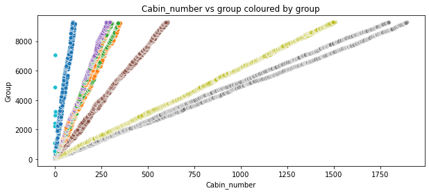

```python
# Scatterplot
plt.figure(figsize=(10,4))
sns.scatterplot(x=data['Cabin_number'], y=data['Group'], c=LabelEncoder().fit_transform(data.loc[~data['Cabin_number'].isna(),'Cabin_deck']), cmap='tab10')
plt.title('Cabin_number vs group coloured by group')
```

cabin_number와 group 간의 상관관계가 있음을 알 수 있음

```python
from sklearn.linear_model import LinearRegression

# Missing values before
CN_bef=data['Cabin_number'].isna().sum()

# Extrapolate linear relationship on a deck by deck basis
for deck in ['A', 'B', 'C', 'D', 'E', 'F', 'G']:
    # Features and labels
    X_CN=data.loc[~(data['Cabin_number'].isna()) & (data['Cabin_deck']==deck),'Group']
    y_CN=data.loc[~(data['Cabin_number'].isna()) & (data['Cabin_deck']==deck),'Cabin_number']
    X_test_CN=data.loc[(data['Cabin_number'].isna()) & (data['Cabin_deck']==deck),'Group']

    # Linear regression
    model_CN=LinearRegression()
    model_CN.fit(X_CN.values.reshape(-1, 1), y_CN)
    preds_CN=model_CN.predict(X_test_CN.values.reshape(-1, 1))

    # Fill missing values with predictions
    data.loc[(data['Cabin_number'].isna()) & (data['Cabin_deck']==deck),'Cabin_number']=preds_CN.astype(int)

# Print number of missing values left
print('#Cabin_number missing values before:',CN_bef)
print('#Cabin_number missing values after:',data['Cabin_number'].isna().sum())
```

```
#Cabin_number missing values before: 299
#Cabin_number missing values after: 0
```

```python
# One-hot encode cabin regions
data['Cabin_region1']=(data['Cabin_number']<300).astype(int)
data['Cabin_region2']=((data['Cabin_number']>=300) & (data['Cabin_number']<600)).astype(int)
data['Cabin_region3']=((data['Cabin_number']>=600) & (data['Cabin_number']<900)).astype(int)
data['Cabin_region4']=((data['Cabin_number']>=900) & (data['Cabin_number']<1200)).astype(int)
data['Cabin_region5']=((data['Cabin_number']>=1200) & (data['Cabin_number']<1500)).astype(int)
data['Cabin_region6']=((data['Cabin_number']>=1500) & (data['Cabin_number']<1800)).astype(int)
data['Cabin_region7']=(data['Cabin_number']>=1800).astype(int)
```

**VIP**

```python
data['VIP'].value_counts()
```

```
False    12401
True       273
Name: VIP, dtype: int64
```

극명하게 갈리는 특성임으로 일괄처리하자

```python
# Missing values before
V_bef=data['VIP'].isna().sum()

# Fill missing values with mode
data.loc[data['VIP'].isna(),'VIP']=False

# Print number of missing values left
print('#VIP missing values before:',V_bef)
print('#VIP missing values after:',data['VIP'].isna().sum())
```

```
#VIP missing values before: 296
#VIP missing values after: 0
```

**Age**  
연령은 관련된 다른 특성들이 너무 많기 때문에 일관적으로 중간값으로 처리한다

```python
# Joint distribution
data.groupby(['HomePlanet','No_spending','Solo','Cabin_deck'])['Age'].median().unstack().fillna(0)
```

| HomePlanet | No_spending | Cabin_deck Solo | A | B | C | D | E | F | G | T |
| --- | --- | --- | --- | --- | --- | --- | --- | --- | --- | --- |
| Earth | 0 | 0 | 0.0 | 0.0 | 0.0 | 0.0 | 24.0 | 25.0 | 28.0 | 0.0 |
|  |  | 1 | 0.0 | 0.0 | 0.0 | 0.0 | 25.0 | 24.0 | 26.0 | 0.0 |
|  | 1 | 0 | 0.0 | 0.0 | 0.0 | 0.0 | 7.0 | 16.0 | 8.0 | 0.0 |
|  |  | 1 | 0.0 | 0.0 | 0.0 | 0.0 | 21.0 | 21.5 | 23.0 | 0.0 |
| Europa | 0 | 0 | 35.0 | 34.0 | 33.0 | 33.0 | 34.0 | 0.0 | 0.0 | 44.0 |
|  |  | 1 | 35.0 | 36.0 | 35.5 | 34.0 | 35.0 | 0.0 | 0.0 | 35.0 |
|  | 1 | 0 | 30.0 | 27.0 | 28.5 | 27.0 | 28.0 | 0.0 | 0.0 | 0.0 |
|  |  | 1 | 37.5 | 34.0 | 35.0 | 31.0 | 33.0 | 0.0 | 0.0 | 0.0 |
| Mars | 0 | 0 | 0.0 | 0.0 | 0.0 | 30.0 | 29.0 | 29.0 | 0.0 | 0.0 |
|  |  | 1 | 0.0 | 0.0 | 0.0 | 31.0 | 28.5 | 30.0 | 0.0 | 0.0 |
|  | 1 | 0 | 0.0 | 0.0 | 0.0 | 29.5 | 26.0 | 18.0 | 0.0 | 0.0 |
|  |  | 1 | 0.0 | 0.0 | 0.0 | 33.0 | 30.0 | 29.5 | 0.0 | 0.0 |

```python
# Missing values before
A_bef=data[exp_feats].isna().sum().sum()

# Fill missing values using the median
na_rows_A=data.loc[data['Age'].isna(),'Age'].index
data.loc[data['Age'].isna(),'Age']=data.groupby(['HomePlanet','No_spending','Solo','Cabin_deck'])['Age'].transform(lambda x: x.fillna(x.median()))[na_rows_A]

# Print number of missing values left
print('#Age missing values before:',A_bef)
print('#Age missing values after:',data['Age'].isna().sum())
```

[output not shown]

```python
# Update age group feature
data.loc[data['Age']<=12,'Age_group']='Age_0-12'
data.loc[(data['Age']>12) & (data['Age']<18),'Age_group']='Age_13-17'
data.loc[(data['Age']>=18) & (data['Age']<=25),'Age_group']='Age_18-25'
data.loc[(data['Age']>25) & (data['Age']<=30),'Age_group']='Age_26-30'
data.loc[(data['Age']>30) & (data['Age']<=50),'Age_group']='Age_31-50'
data.loc[data['Age']>50,'Age_group']='Age_51+'
```

**CryoSleep**

```python
# Joint distribution
data.groupby(['No_spending','CryoSleep'])['CryoSleep'].size().unstack().fillna(0)
```

| CryoSleep No_spending | False | True |
| --- | --- | --- |
| 0 | 7339.0 | 0.0 |
| 1 | 740.0 | 4581.0 |

소비가 0이면 냉동 상태라고 정리한다

```python
# Missing values before
CSL_bef=data['CryoSleep'].isna().sum()

# Fill missing values using the mode
na_rows_CSL=data.loc[data['CryoSleep'].isna(),'CryoSleep'].index
data.loc[data['CryoSleep'].isna(),'CryoSleep']=data.groupby(['No_spending'])['CryoSleep'].transform(lambda x: x.fillna(pd.Series.mode(x)[0]))[na_rows_CSL]

# Print number of missing values left
print('#CryoSleep missing values before:',CSL_bef)
print('#CryoSleep missing values after:',data['CryoSleep'].isna().sum())
```

```
#CryoSleep missing values before: 310
#CryoSleep missing values after: 0
```

**Expenditure과 CryoSleep**  
앞의 처리의 반대

```python
print('Maximum expenditure of passengers in CryoSleep:',data.loc[data['CryoSleep']==True,exp_feats].sum(axis=1).max())
```

```
Maximum expenditure of passengers in CryoSleep: 0.0
```

```python
# Missing values before
E_bef=data[exp_feats].isna().sum().sum()

# CryoSleep has no expenditure
for col in exp_feats:
    data.loc[(data[col].isna()) & (data['CryoSleep']==True), col]=0

# Print number of missing values left
print('#Expenditure missing values before:',E_bef)
print('#Expenditure missing values after:',data[exp_feats].isna().sum().sum())
```

```
#Expenditure missing values before: 1410
#Expenditure missing values after: 866
```

**Expenditure과 others**

```python
# Joint distribution
data.groupby(['HomePlanet','Solo','Age_group'])['Expenditure'].mean().unstack().fillna(0)
```

| HomePlanet | Age_group Solo | Age_0-12 | Age_13-17 | Age_18-25 | Age_26-30 | Age_31-50 | Age_51+ |
| --- | --- | --- | --- | --- | --- | --- | --- |
| Earth | 0 | 0.0 | 724.902222 | 789.700555 | 841.093596 | 736.655773 | 733.649573 |
|  | 1 | 0.0 | 693.014898 | 779.395942 | 795.420690 | 794.818627 | 826.366972 |
| Europa | 0 | 0.0 | 1153.160256 | 2652.013298 | 3534.668246 | 3975.774005 | 3483.639004 |
|  | 1 | 0.0 | 0.000000 | 2489.888889 | 3806.000000 | 3949.939929 | 3952.085526 |
| Mars | 0 | 0.0 | 1176.839286 | 1161.808333 | 1247.098361 | 1143.671916 | 1345.419643 |
|  | 1 | 0.0 | 1687.261538 | 1075.341146 | 1107.122677 | 1110.392045 | 1100.298387 |

지출은 여러가지 요소에 영향을 받는데 이상치가 많으므로 이에대한 중앙값이 아니라 평균값으로 계산한다

```python
# Missing values before
E_bef=data[exp_feats].isna().sum().sum()

# Fill remaining missing values using the median
for col in exp_feats:
    na_rows=data.loc[data[col].isna(),col].index
    data.loc[data[col].isna(),col]=data.groupby(['HomePlanet','Solo','Age_group'])[col].transform(lambda x: x.fillna(x.mean()))[na_rows]

# Print number of missing values left
print('#Expenditure missing values before:',E_bef)
print('#Expenditure missing values after:',data[exp_feats].isna().sum().sum())
```

```
#Expenditure missing values before: 866
#Expenditure missing values after: 0
```

지출여부 특성 추가

```python
# Update expenditure and no_spending
data['Expenditure']=data[exp_feats].sum(axis=1)
data['No_spending']=(data['Expenditure']==0).astype(int)
```

결측치 최종확인

```python
data.isna().sum()
```

```
PassengerId      0
HomePlanet       0
CryoSleep        0
Destination      0
Age              0
VIP              0
RoomService      0
FoodCourt        0
ShoppingMall     0
Spa              0
VRDeck           0
Age_group        0
Expenditure      0
No_spending      0
Group            0
Group_size       0
Solo             0
Cabin_deck       0
Cabin_number     0
Cabin_side       0
Cabin_region1    0
Cabin_region2    0
Cabin_region3    0
Cabin_region4    0
Cabin_region5    0
Cabin_region6    0
Cabin_region7    0
Family_size      0
dtype: int64
```

모든 결측치 제거

```python
# 데이터 분리
X=data[data['PassengerId'].isin(train['PassengerId'].values)].copy()
X_test=data[data['PassengerId'].isin(test['PassengerId'].values)].copy()
```

```python
# 필요없는 컬럼 제거
X.drop(['PassengerId', 'Group', 'Group_size', 'Age_group', 'Cabin_number'], axis=1, inplace=True)
X_test.drop(['PassengerId', 'Group', 'Group_size', 'Age_group', 'Cabin_number'], axis=1, inplace=True)
```

```python
X['Transported'] = train['Transported']
```

```python
X.to_csv("./data/train01.csv", mode='w', index=False)
X_test.to_csv("./data/test01.csv", mode='w', index=False)
```